# Computational Social Science Workshop Calendar

## Fall 2018

### Thursday’s, 11:00am-12:20pm, Kent 120

### October 4th - [Mixer with CSS Faculty](https://macss.uchicago.edu/content/meet-our-faculty-staff)

[figure not shown]

### October 18th - [Zizi Pappachrissi](https://zizi.people.uic.edu/Site/ziziweb.html)

[figure not shown]

###### Professor and Department Head of Communication, Professor of Political Science, University of Illinois at Chicago

##### [*Affective Publics: News Storytelling, Sentiment and Technology*](https://github.com/uchicago-computation-workshop/zizi-pappachrissi)

### October 25th - TBD

### November 1st - TBD

### November 8th - TBD

### November 15th - TBD

### November 29th - TBD

# Winter 2018

### Thursday’s, 11:00am-12:20pm, Kent 120

### January 11th - [Ali Hortaçsu](https://economics.uchicago.edu/directory/ali-hortacsu)

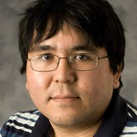

###### The Ralph and Mary Otis Isham Professor in Economics and the College, University of Chicago

##### [*Trade, Merchants, and the Lost Cities of the Bronze Age*](https://github.com/uchicago-computation-workshop/ali_hortacsu)

### January 18th - [Anna Mueller](http://humdev.uchicago.edu/directory/anna-mueller)

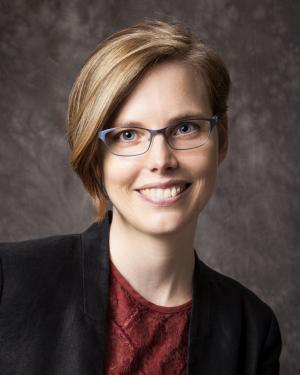

###### Assistant Professor, Department of Comparative Human Development and the College, University of Chicago

##### [*Why Networks Matter to Suicide: Examining the Cultural Underpinnings of Suicide Diffusion in Adolescence*](https://github.com/uchicago-computation-workshop/anna_mueller)

### January 25th - [James Evans](https://macss.uchicago.edu/directory/james-evans)

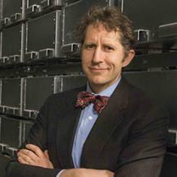

###### Director, Knowledge Lab; Professor, Sociology, University of Chicago; Senior Fellow, Computation Institute; Faculty Director, Masters Program in Computational Social Sciences, University of Chicago

##### [*The Wisdom of Polarized Crowds*](https://github.com/uchicago-computation-workshop/james_evans)

### February 1st - [Richard Evans](https://macss.uchicago.edu/directory/rick-evans)

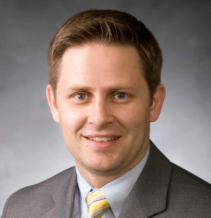

###### Senior Lecturer in Computational Social Science; Director, Open Source Macroeconomics Laboratory; Fellow, Becker Friedman Institute, University of Chicago

##### [*Open Source Modeling for Policy Analysis and Research*](https://github.com/uchicago-computation-workshop/richard_evans)

### February 15th - [Leslie Kay](https://imb.uchicago.edu/directory/leslie-m-kay-phd)

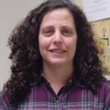

###### Professor, Department of Psychology and The College, University of Chicago

##### [*How the Questions We Ask Affect the Answers We Get: A Lesson from Asking Rats How They Smell*](https://github.com/uchicago-computation-workshop/leslie_kay)

### February 22nd - [Laura Nelson](https://www.northeastern.edu/cssh/faculty/laura-nelson)

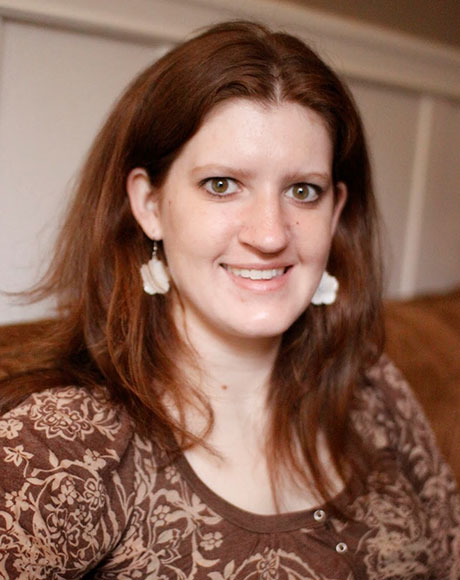

###### Assistant Professor of Sociology, College of Social Sciences and Humanities, Northeastern University

##### [*Cycles of Conflict, A Century of Continuity: Using Computational Methods to Measure Why Some Ideas Succeed and Others Fail*](https://github.com/uchicago-computation-workshop/laura_nelson)

# Spring 2018

### Thursday’s, 11:00am-12:20pm, Kent 120

### March 29th - [MACSS Student Conference](https://macss.uchicago.edu/)

[figure not shown]

###### An Opportunity for Second Year MACSS Students to Present Their Thesis Research

##### [*2nd Year Lightning Talks*](https://github.com/uchicago-computation-workshop/2018_spring_conference)

###### *NOTE: Special Time and Location:* **Thursday, 5-7pm - Social Science Research Building 122**

### April 5th - [Chris Bail](http://www.chrisbail.net)

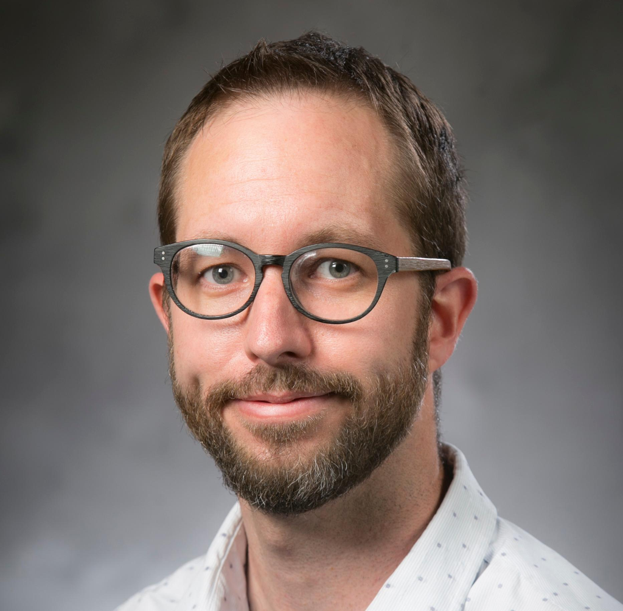

###### Douglas and Ellen Lowey Associate Professor of Sociology and Public Policy, Duke University

##### [*Talk Title TBD*](https://github.com/uchicago-computation-workshop/chris_bail)

### April 12th - [Ben Golub](http://www.people.fas.harvard.edu/~bgolub/)

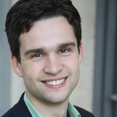

###### Assistant Professor, Department of Economics, Harvard University

##### [*Talk Title TBD*](https://github.com/uchicago-computation-workshop/ben_golub)

### April 26th - [Paolo Parigi](https://www.linkedin.com/in/paolo-parigi-085782b/)

[figure not shown]

###### Lead Trust Scientist, Airbnb

##### [*Talk Title TBD*](https://github.com/uchicago-computation-workshop/paolo_parigi)

### May 4th - [Glen Weyl](http://glenweyl.com)

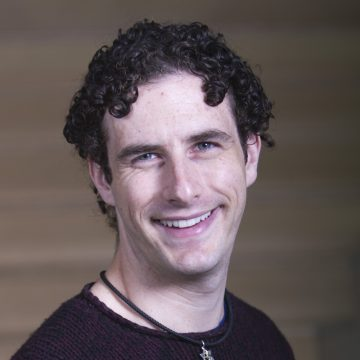

###### Principal Researcher at Microsoft Research New England, Visiting Senior Research Scholar, Yale University

##### [*Talk Title TBD*](https://github.com/uchicago-computation-workshop/glen_weyl)

###### *NOTE: Special Time and Location:* **Friday - TBD**

### May 10th - [Kathleen Cagney](https://sociology.uchicago.edu/directory/kathleen-cagney)

###### Associate Professor, Sociology; Health Studies Director, Population Research Center, NORC; Executive Committee Member, Masters in Computational Social Science Program, University of Chicago

##### [*Talk Title TBD*](https://github.com/uchicago-computation-workshop/kathleen_cagney)

### May 17th - [Andres Gomez](https://growthlab.cid.harvard.edu/people/andres-gomez)

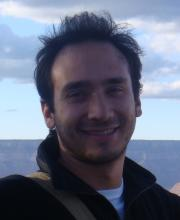

###### Postdoctoral Fellow at the Center for International Development, Harvard University

##### [*Talk Title TBD*](https://github.com/uchicago-computation-workshop/andres_gomez)

### May 24th - [Bogdan State](https://www.linkedin.com/in/bogdan-state-72782a53/)

[figure not shown]

##### [*Talk Title TBD*](https://github.com/uchicago-computation-workshop/bogdan_state)